# The Effect of Medicaid Expansion on Healthcare Worker Wages

- Show All Code
- Hide All Code
- View Source

A Triple-Difference Analysis

Author

Affiliation

Karan Mandair

Old Dominion University

## Introduction

The Affordable Care Act’s Medicaid expansion in January 2014 extended coverage to millions of newly insured Americans, creating one of the largest demand shocks to hit the healthcare labor market in recent times. Policymakers and researchers pre-expansion strongly predicted that having millions of newly insured patients flooding into a workforce that is somewhat constrained by years of licensing requirements, would force healthcare organizations to raise wages to compete for scarce workers. Frogner et al. (2015) projected that 3 to 4 million additional healthcare workers would be needed by 2022, while Parente et al. (2017) modeled significant upward wage pressure from an inelastic labor supply meeting a large sudden demand shock. Whether these predictions proved accurate has never been tested with an adequate control group and a direct measure of hourly wages.

This paper fills that gap. Using American Community Survey microdata from 2010 to 2017 and a triple difference-in-differences design, I estimate the effect of Medicaid expansion on healthcare worker wages. The identifying variation comes from comparing how the wage gap between healthcare workers and public service workers (teachers, police officers, firefighters, and social workers) evolved differently in expansion versus non-expansion states before and after January 2014. Public service workers serve as the control group because they share similar education levels and institutional settings with healthcare workers but had no exposure to the Medicaid expansion directly. The primary outcome is log annual wage and salary income, following Matta et al. (2024), with hourly wages and hours worked per week examined as robustness checks to distinguish wage rate changes from hours changes.

The main finding of this paper is that Medicaid expansion had no significant effect on healthcare worker wages. The triple difference-in-differences coefficient is -0.005 with a standard error of 0.009 under state and year fixed effects, and -0.007 with a standard error of 0.009 under the most demanding specification using state-by-year, healthcare-by-state, and healthcare-by-year fixed effects. In both specifications, the estimates are small and statistically insignificant. Furthermore, the null result is robust to alternative outcome variables including log hourly wages and hours worked per week, and holds across all three education tiers of healthcare workers including postgraduate, bachelors, and no-college occupations, suggesting the absence of wage effects is not concentrated in any particular group.

This paper makes three contributions to the existing literature. First, it tests Medicaid expansion wage effects using hourly wages and hours worked per week, alongside annual income, allowing a cleaner separation of wage rate changes from hours changes. Second, it introduces a public service worker control group to absorb broader economic trends that would otherwise contaminate a direct comparison of healthcare workers across expansion and non-expansion states. Expansion states had stronger wage growth than non-expansion states for reasons unrelated to Medicaid, and a simple comparison cannot strip this out. Third, it provides a direct empirical test of the pre-expansion wage pressure predictions that dominated pre-expansion policy debates, finding no evidence that the predicted upward wage pressure actually occurred.

The remainder of the paper proceeds as follows. Section 2 reviews the literature on Medicaid expansion and healthcare labor markets. Section 3 describes the data and sample construction. Section 4 presents the empirical strategy. Section 5 presents the main results and robustness checks. Section 6 concludes.

## Literature Review

### The ACA Medicaid Expansion and Coverage Effects

The Affordable Care Act (ACA) of 2010 expanded Medicaid eligibility to all adults with incomes up to 138% of the federal poverty level. Before the ACA, Medicaid covered only specific groups, leaving millions of low-income childless adults ineligible regardless of their poverty level. However, the 2012 Supreme Court decision in *NFIB v. Sebelius* made expansion optional, creating a natural experiment: beginning January 2014, twenty-six states plus the District of Columbia expanded Medicaid while the remainder declined. This state-level variation allows researchers to identify causal effects by comparing expansion and non-expansion states over time.

The expansion significantly increased coverage. Using difference-in-differences designs, studies consistently find that expansion states experienced 5-8 percentage point larger reductions in uninsured rates compared to non-expansion states (Sommers et al. 2015; Miller and Wherry 2017). Frean, Gruber, and Sommers (2017) decompose ACA coverage gains and find that Medicaid expansion accounted for approximately 60% of total new coverage under the ACA. This made Medicaid expansion the primary channel through which the ACA increased insurance coverage. These coverage gains created a large and sudden demand shock for healthcare services, raising the question of whether the healthcare workforce could absorb millions of newly insured patients without significant upward wage pressure.

### Healthcare Labor Market Responses to Expansion

#### Supply Constraints and Pre-Expansion Projections

Healthcare labor markets have unique characteristics that shape their response to demand shocks. Most healthcare occupations require occupational licenses that take years to obtain, restricting the speed at which new workers can enter the workforce. Kleiner and Krueger (2013) find that licensed workers earn approximately 18% more than comparable unlicensed workers, suggesting these barriers meaningfully compress labor supply. The nursing workforce shows how supply responds to economic conditions more broadly: Staiger, Auerbach, and Buerhaus (2012) find that nurse labor supply is countercyclical, with nurses working more hours during recessions and fewer during expansions, indicating that available supply also depends heavily on broader economic conditions, rather than just wages alone.

These supply constraints led pre-expansion researchers to predict significant wage pressure. Frogner et al. (2015) projected that the healthcare industry would need 3 to 4 million additional workers by 2022. Parente et al. (2017) used economic modeling to project that inelastic labor supply combined with a large demand shock would force healthcare organizations to raise wages to compete for scarce workers, driving up healthcare costs. Both projections rested on two assumptions: that labor supply was difficult to expand quickly, and that demand increases would be large enough to strain existing capacity. Whether these projections proved accurate has never been tested with a control group and a direct measure of hourly wages, which is the gap this paper addresses directly.

#### Employment and Hours Responses

The evidence shows that healthcare organizations responded to Medicaid expansion primarily by hiring more workers rather than through other adjustments. Dillender (2022) analyzes over 14 million job vacancy postings and finds that healthcare employers in expansion states posted significantly more openings and hired more workers than those in non-expansion states, with effects strongest for lower-skilled positions. At the hospital level, Meille and Post (2023) find that expansion increased emergency department and outpatient visits, with hospitals responding primarily by hiring more nurses rather than expanding physician staff or making capital investments.

While employers actively recruited and posted vacancies, the net size of the healthcare workforce did not expand dramatically. Multiple studies using different datasets and methods consistently find that Medicaid expansion did not reduce employment among low-income adults (Gooptu et al. 2016; Kaestner et al. 2017; Leung and Mas 2018; Duggan, Goda, and Jackson 2019). For healthcare workers specifically, DiNardi (2021) finds that expansion increased the average workweek by 30-50 minutes for registered and licensed practical nurses, driven by more nurses working full-time rather than part-time. Registered nurses became 3 percentage points more likely to work full-time, and licensed practical nurses became 5 percentage points more likely. Importantly, this hours response occurred without a large increase in the overall nurse employment levels, suggesting organizations met some increased demand by extending existing workers’ hours rather than by raising wages to attract new ones.

For lower-skilled workers, the pattern diverges. Xu, Sharma, and Wehby (2024) find that nursing assistants in nursing homes became 4.4 percentage points more likely to work part-time following expansion. This pattern suggests that responses to Medicaid expansion may have varied by skill level within the healthcare workforce.

#### Wage Effects

Despite upward wage pressure being a central concern in pre-expansion debates, surprisingly few studies have directly examined healthcare worker wages following Medicaid expansion. The most comprehensive analysis comes from Matta, Chatterjee, and Venkataramani (2024), who analyze annual income data for over 1.3 million healthcare workers between 2010 and 2019. They find that expansion was associated with a 2.16% increase in annual income overall, but this average masks distributional differences. Income gains were concentrated among the top two quintiles of earners, predominantly registered nurses, physicians, and managers, while workers in the bottom three quintiles, including nursing aides and other support staff, experienced no significant income changes. The expansion was also associated with a 3.15 percentage point increase in the likelihood that healthcare workers received Medicaid themselves, with the largest gains concentrated among the two lowest-earning quintiles. This was accompanied by a decline in employer-sponsored insurance for low-wage workers, suggesting that rather than raising wages, some healthcare organizations reduced benefits knowing their employees now qualified for public coverage.

This crowd-out pattern is specifically evident in nursing homes. Xu and Sharma (2023) find that low-income nursing home aides experienced a 12.2 percentage point increase in Medicaid enrollment but a 6.4 percentage point reduction in employer-sponsored private insurance coverage. Workers in these settings gained insurance access through Medicaid but neither received wage increases nor retained their employer benefits, a pattern consistent with employers using expansion as an opportunity to reduce compensation costs rather than improve worker welfare.

Taken together, the wages evidence points to a pattern of heterogeneous effects, with positive gains for higher-skilled workers, no gains for lower-skilled workers, and potential benefit reductions at the bottom of the distribution. What remains unclear is whether these income effects reflect actual changes in hourly wage rates or simply changes in hours worked. Distinguishing between these two mechanisms is important because a worker earning more annual income due to longer hours is fundamentally different from one receiving a higher wage rate, yet existing studies using annual income cannot separate the two. This is the gap this paper aims to address.

### What This Study Adds

The existing research on the Medicaid expansion found that it increased coverage substantially. Furthermore, healthcare organizations responded by hiring more workers to meet rising patient demand, and the newly insured did not reduce their labor force participation as a result of gaining coverage. Wage effects were also heterogeneous and concentrated at the top of the distribution, with higher-skilled workers seeing modest gains and lower-skilled workers seeing basically none. However, there are three critical gaps that remain.

First, no study has used hourly wages as a robustness check against annual income. Matta et al. (2024) analyze annual income, which mixes wage rates and hours worked. Hourly wages are an important alternative measure because they directly capture whether workers are actually being paid more per hour, which is what the pre-expansion wage predictions were specifically concerned with. A worker earning more annual income simply because they work more hours is a completely different outcome from a worker receiving a higher hourly wage. Most existing studies rely on the ACS, CPS, or administrative claims data, none of which have been used to construct a consistent hourly wage measure across the full pre and post expansion window.

Second, existing studies fail to have a proper control group. When comparing healthcare workers in expansion states to healthcare workers in non-expansion states, we cannot cleanly separate Medicaid expansion effects from other state differences. These could include things like economic growth rates, political environments, and pre existing healthcare trends. Another issue is that generally, expansion states were experiencing stronger overall wage growth during this period, reflecting broader economic and political differences between states that chose to expand Medicaid and those that did not. Therefore, not having an adequate control group and making simple comparisons of healthcare workers across expansion and non-expansion states, cannot isolate the expansion effect from these broader trends.

Third, while Matta et al. (2024) provide the most direct test to date, their annual income measure and lack of a control group leave the core prediction largely unresolved. The pre-expansion debate strongly predicted wage pressure. Frogner et al. (2015) and Parente et al. (2017) predicted that millions of newly insured patients plus a workforce constrained by years of licensing requirements would create upward wage pressure. Whether this prediction held has not been cleanly tested. Existing evidence suggests the wage increase did not materialize, but the mechanism behind this null result remains unresolved. Whether healthcare labor supply was simply more flexible than pre-expansion projections assumed, or whether organizations absorbed increased demand through employment and hours margins rather than wage adjustment, has not been cleanly established with an appropriate control group and a direct measure of hourly wages.

This study tackles all three gaps directly. The primary outcome is log annual wage, following Matta et al. (2024), with hourly wages and hours worked examined as robustness checks to distinguish wage rate changes from hours changes. For identification, I use a triple difference-in-differences design comparing healthcare workers to public service workers, including teachers, police officers, firefighters, and social workers, across expansion and non-expansion states from 2010-2017. This control group works well because these workers share similar education levels and work in similar public and professional settings, but had no direct connection to the Medicaid expansion. By comparing how the gap between healthcare and public service wages changed differently in expansion versus non-expansion states, I can strip out broader economic trends that would otherwise contaminate a simpler comparison without a proper control group. Together, these choices allow me to directly test whether the upward wage pressure that policymakers and researchers predicted before expansion actually materialized.

## Data

### Data Sources

The primary data source for this analysis is the American Community Survey (ACS), accessed through IPUMS USA. The ACS is a large, nationally representative household survey conducted annually by the Census Bureau that collects detailed information on employment, earnings, occupation, and demographics for millions of Americans each year. I use the 2010 to 2017 waves, which span four years before and four years after the January 2014 Medicaid expansion.

The ACS is well suited for this analysis for three reasons. First, its large sample size allows reliable estimation for specific occupation groups at the state level, which is essential for comparing healthcare and public service workers across expansion and non-expansion states. Second, it contains both annual wage and salary income (INCWAGE) and usual hours worked per week (UHRSWORK), which together allow construction of an hourly wage measure. Third, it covers the full pre- and post-expansion window with consistent variable definitions, making year-over-year comparisons straightforward.

The primary outcome variable is log annual wage and salary income, which follows the approach of Matta et al. (2024) and allows direct comparison with their findings. Hourly wages are constructed by dividing annual income by estimated annual hours worked, where annual hours are the product of usual weekly hours (UHRSWORK) and the midpoint of the weeks worked category (WKSWORK2), since the ACS records weeks worked as a bracket rather than an exact number. Occupation is identified using the Census occupation code (OCC), and state of residence is identified using STATEFIP. Demographic controls include age, sex, race, ethnicity, and educational attainment.

Finally, the ACS provides person-level survey weights (PERWT) that adjust for the fact that some groups are sampled more or less frequently than others. All specifications use these weights to ensure estimates are representative of the national healthcare and public service workforce.

### Sample Construction

```r
restrictions <- data.frame(
  Description = c(
    "Raw IPUMS ACS 2010-2017",
    "Employed (EMPSTAT = 1)",
    "Age 25-64",
    "Valid wages ($1-$999,997)",
    "Worked positive weeks/hours",
    "In household/group quarters",
    "Healthcare + Public Service workers only",
    "Exclude late-expanding states"
  ),
  `Sample Size` = c(
    format(n$step0, big.mark = ","),
    format(n$step1, big.mark = ","),
    format(n$step2, big.mark = ","),
    format(n$step3, big.mark = ","),
    format(n$step4, big.mark = ","),
    format(n$step5, big.mark = ","),
    format(n$step9, big.mark = ","),
     format(nrow(analysis_sample_early), big.mark = ",")
  ),
  check.names = FALSE,
  stringsAsFactors = FALSE
)

kable(restrictions, align = c("l", "r"))
```

Table 1: Sample Construction and Restrictions

| Description | Sample Size |
| --- | --- |
| Raw IPUMS ACS 2010-2017 | 25,045,676 |
| Employed (EMPSTAT = 1) | 11,341,036 |
| Age 25-64 | 9,287,052 |
| Valid wages ($1-$999,997) | 8,744,449 |
| Worked positive weeks/hours | 8,744,449 |
| In household/group quarters | 8,695,737 |
| Healthcare + Public Service workers only | 1,955,451 |
| Exclude late-expanding states | 1,730,930 |

### Sample

The analysis uses IPUMS ACS data from 2010 to 2017, restricted to the 1,730,930 observations in states that either expanded Medicaid in January 2014 or never expanded. States that adopted Medicaid after 2014 are excluded to avoid contaminating the control group with labor market responses to expansion. The sample is further restricted to 2010 to 2017 to avoid a Census Bureau occupation code reclassification that took effect in 2018. The reclassification replaced 14 pre-existing healthcare occupation codes with 23 new codes, making it impossible to consistently define healthcare workers across the full sample period. Workers are restricted to those aged 25 to 64 with positive reported wages and hours. The pre-period runs from 2010 to 2013 and the post-period from 2014 to 2017, with 2014 included as post given the policy took effect on January 1st 2014.

### Descriptive Statistics

```r
table3_data <- analysis_sample_early %>%
  mutate(
    treatment_group = case_when(
      healthcare_worker == 1 & !is.na(expansion_year) ~ "Healthcare - Expansion",
      healthcare_worker == 1 & is.na(expansion_year) ~ "Healthcare - Non-Expansion",
      public_service_worker == 1 & !is.na(expansion_year) ~ "Public Service - Expansion",
      public_service_worker == 1 & is.na(expansion_year) ~ "Public Service - Non-Expansion"
    )
  ) %>%
  group_by(treatment_group) %>%
  summarize(
    N = n(),
    `Mean Hourly Wage` = mean(hourly_wage, na.rm = TRUE),
    `Mean Age` = mean(AGE, na.rm = TRUE),
    `% Female` = mean(female, na.rm = TRUE) * 100,
    `% College+` = mean(college_plus, na.rm = TRUE) * 100,
    `% Medicaid` = mean(has_medicaid, na.rm = TRUE) * 100,
    `Mean Hours` = mean(UHRSWORK, na.rm = TRUE)
  )

kable(table3_data,
      digits = 2,
      format.args = list(big.mark = ","))
```

Table 2: Summary Statistics by Treatment Group

| treatment_group | N | Mean Hourly Wage | Mean Age | % Female | % College+ | % Medicaid | Mean Hours |
| --- | --- | --- | --- | --- | --- | --- | --- |
| Healthcare - Expansion | 415,067 | 34.83 | 43.93 | 79.20 | 48.91 | 6.43 | 38.63 |
| Healthcare - Non-Expansion | 261,992 | 31.04 | 43.50 | 79.94 | 43.91 | 3.24 | 39.47 |
| Public Service - Expansion | 659,676 | 30.81 | 43.77 | 60.81 | 73.11 | 4.10 | 40.16 |
| Public Service - Non-Expansion | 394,195 | 24.02 | 43.88 | 62.16 | 70.30 | 2.10 | 41.35 |

```r
vars_summary <- analysis_sample_early %>%
  transmute(
    `Log Annual Income` = log(INCWAGE),
    `Hourly Wage ($)`   = hourly_wage,
    `Hours Worked`      = UHRSWORK,
    `Age`               = AGE,
    `Female`            = female,
    `College+`          = college_plus,
    `Black`             = black,
    `Hispanic`          = hispanic,
    `Has Medicaid`      = as.numeric(has_medicaid),
    `Has Employer Ins.` = as.numeric(has_employer),
    `Uninsured`         = as.numeric(uninsured)
  )

summary_tbl <- vars_summary %>%
  summarise(across(everything(), list(
    Mean   = ~round(mean(., na.rm = TRUE), 3),
    SD     = ~round(sd(., na.rm = TRUE), 3),
    Min    = ~round(min(., na.rm = TRUE), 3),
    Median = ~round(median(., na.rm = TRUE), 3),
    Max    = ~round(max(., na.rm = TRUE), 3)
  ))) %>%
  pivot_longer(everything(),
               names_to  = c("Variable", ".value"),
               names_pattern = "^(.+)_(Mean|SD|Min|Median|Max)$")

kable(summary_tbl, digits = 3, format.args = list(big.mark = ","))
```

Table 3: Summary Statistics — Full Analysis Sample

| Variable | Mean | SD | Min | Median | Max |
| --- | --- | --- | --- | --- | --- |
| Log Annual Income | 10.601 | 0.939 | 1.386 | 10.714 | 13.509 |
| Hourly Wage ($) | 30.265 | 87.123 | 0.001 | 22.876 | 91,142.857 |
| Hours Worked | 39.959 | 11.531 | 1.000 | 40.000 | 99.000 |
| Age | 43.791 | 11.137 | 25.000 | 44.000 | 64.000 |
| Female | 0.684 | 0.465 | 0.000 | 1.000 | 1.000 |
| College+ | 0.622 | 0.485 | 0.000 | 1.000 | 1.000 |
| Black | 0.101 | 0.301 | 0.000 | 0.000 | 1.000 |
| Hispanic | 0.096 | 0.294 | 0.000 | 0.000 | 1.000 |
| Has Medicaid | 0.041 | 0.198 | 0.000 | 0.000 | 1.000 |
| Has Employer Ins. | 0.832 | 0.374 | 0.000 | 1.000 | 1.000 |
| Uninsured | 0.057 | 0.232 | 0.000 | 0.000 | 1.000 |

## Descriptive Evidence

### First Stage: Medicaid Coverage

```r
medicaid_coverage <- analysis_sample_early %>%
  mutate(expansion_status = ifelse(is.na(expansion_year), "Non-Expansion States", "Expansion States")) %>%
  group_by(YEAR, expansion_status) %>%
  summarize(
    medicaid_rate = mean(has_medicaid, na.rm = TRUE) * 100,
    se = sd(has_medicaid, na.rm = TRUE) / sqrt(n()) * 100,
    .groups = "drop"
  ) %>%
  mutate(
    ci_lower = medicaid_rate - 1.96 * se,
    ci_upper = medicaid_rate + 1.96 * se
  )

ggplot(medicaid_coverage, aes(x = YEAR, y = medicaid_rate, linetype = expansion_status)) +
  geom_ribbon(aes(ymin = ci_lower, ymax = ci_upper), alpha = 0.15, color = NA, fill = "gray60") +
  geom_line(linewidth = 0.9, color = "black") +
  geom_point(size = 2, color = "black") +
  geom_vline(xintercept = 2014, linetype = "dashed", color = "black", linewidth = 0.8) +
  scale_x_continuous(breaks = 2010:2017) +
  scale_y_continuous(limits = c(0, 7), breaks = 0:7) +
  scale_linetype_manual(values = c("Expansion States" = "solid",
                                   "Non-Expansion States" = "dashed")) +
  labs(x = "Year", y = "Medicaid Coverage Rate (%)", linetype = NULL) +
  theme_minimal(base_size = 12) +
  theme(legend.position = "bottom",
        axis.text.x = element_text(angle = 45, hjust = 1),
        legend.key.width = unit(2, "cm"),
        panel.grid.minor = element_blank())
```

**Plot**

**Figure 1.** Medicaid Coverage Rates by State Expansion Status

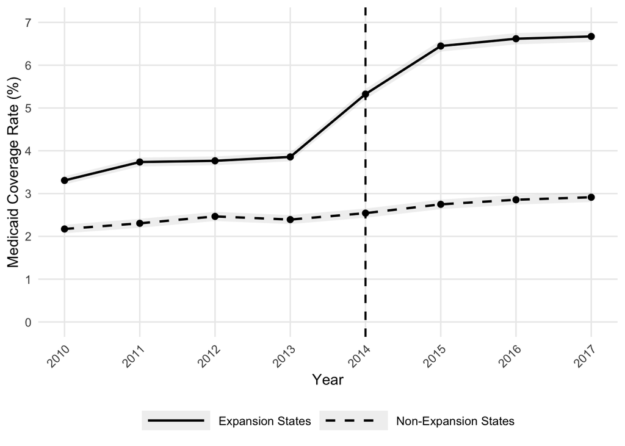

### Wage Trends and Parallel Trends

```r
log_wage_trends <- analysis_sample_early %>%
  mutate(
    treatment_group = case_when(
      healthcare_worker == 1 & !is.na(expansion_year) ~ "Healthcare - Expansion States",
      healthcare_worker == 1 & is.na(expansion_year) ~ "Healthcare - Non-Expansion States",
      public_service_worker == 1 & !is.na(expansion_year) ~ "Control - Expansion States",
      public_service_worker == 1 & is.na(expansion_year) ~ "Control - Non-Expansion States"
    )
  ) %>%
  group_by(YEAR, treatment_group) %>%
  summarize(
    mean_log_wage = mean(log(INCWAGE), na.rm = TRUE),
    se_log_wage = sd(log(INCWAGE), na.rm = TRUE) / sqrt(n()),
    .groups = "drop"
  ) %>%
  mutate(ci_lower = mean_log_wage - 1.96 * se_log_wage, ci_upper = mean_log_wage + 1.96 * se_log_wage)

ggplot(log_wage_trends, aes(x = YEAR, y = mean_log_wage,
                             linetype = treatment_group,
                             shape = treatment_group)) +
  geom_ribbon(aes(ymin = ci_lower, ymax = ci_upper),
              alpha = 0.1, color = NA, fill = "gray60") +
  geom_line(linewidth = 0.9, color = "black") +
  geom_point(size = 3, color = "black") +
  geom_vline(xintercept = 2014, linetype = "dashed", color = "black", linewidth = 0.8) +
  scale_x_continuous(breaks = 2010:2017) +
  scale_linetype_manual(values = c(
    "Healthcare - Expansion States"     = "solid",
    "Healthcare - Non-Expansion States" = "longdash",
    "Control - Expansion States"        = "dotted",
    "Control - Non-Expansion States"    = "dotdash"
  )) +
  scale_shape_manual(values = c(
    "Healthcare - Expansion States"     = 16,
    "Healthcare - Non-Expansion States" = 17,
    "Control - Expansion States"        = 15,
    "Control - Non-Expansion States"    = 18
  )) +
  labs(x = "Year", y = "Log Annual Income", linetype = NULL, shape = NULL) +
  theme_minimal(base_size = 12) +
  theme(legend.position = "bottom",
        axis.text.x = element_text(angle = 45, hjust = 1),
        legend.key.width = unit(2, "cm"),
        panel.grid.minor = element_blank()) +
  guides(linetype = guide_legend(nrow = 2),
         shape = guide_legend(nrow = 2))
```

**Plot**

**Figure 2.** Log Annual Income Over Time by Treatment Group

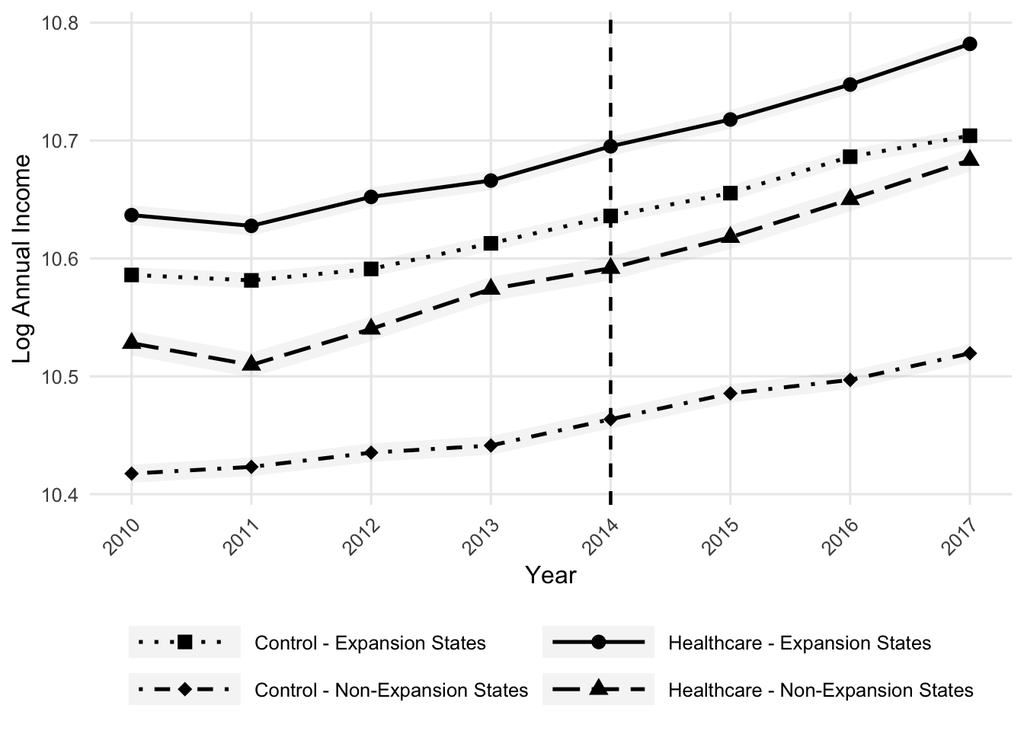

## Empirical Strategy

The simplest approach to estimating the effect of Medicaid expansion on healthcare worker wages is a standard difference-in-differences comparing healthcare workers in expansion states to those in non-expansion states before and after January 2014:

$$\log(\text{wage}_{ist}) = \alpha + \beta(\text{Post2014}_t \times \text{Expansion}_s) + X_{ist}'\gamma + \alpha_s + \lambda_t + \varepsilon_{ist}$$

This is estimated separately for healthcare workers (Column 1) and public service workers (Column 2), where Column 2 serves as a placebo test. However, expansion states were generally doing better economically during this period, meaning healthcare wages in those states may have grown faster due to stronger local economies rather than anything to do with Medicaid expansion itself. A simple comparison of healthcare workers across expansion and non-expansion states cannot separate the policy effect from these broader trends.

To address this, I add a second comparison group, which is public service workers including teachers, police officers, firefighters, and social workers. These workers share similar education levels and work in similar public and professional settings, but had no direct connection to Medicaid expansion. By tracking how the gap between healthcare and public service wages changed differently in expansion versus non-expansion states, the triple difference-in-differences design strips out broader economic trends:

$$\begin{align}
\log(\text{wage}_{ist}) = &\beta_0 + \beta_1(\text{Healthcare}_i) + \beta_2(\text{Post2014}_t) + \beta_3(\text{Expansion}_s) \\
&+ \beta_4(\text{Healthcare}_i \times \text{Post2014}_t) + \beta_5(\text{Healthcare}_i \times \text{Expansion}_s) \\
&+ \beta_6(\text{Post2014}_t \times \text{Expansion}_s) \\
&+ \delta(\text{Healthcare}_i \times \text{Post2014}_t \times \text{Expansion}_s) \\
&+ X_{ist}'\gamma + \alpha_s + \lambda_t + \varepsilon_{ist}
\end{align}$$

The coefficient of interest $\delta$ captures the triple-difference estimate:

$$\delta = [\Delta\text{Wage}_{\text{HC}}^{\text{Expansion}} - \Delta\text{Wage}_{\text{HC}}^{\text{NonExpansion}}] - [\Delta\text{Wage}_{\text{PS}}^{\text{Expansion}} - \Delta\text{Wage}_{\text{PS}}^{\text{NonExpansion}}]$$

If $\delta$ is positive and significant, this is evidence that expansion raised wages for healthcare workers. If it is close to zero, the labor market absorbed the surge in patients without pushing wages up.

I estimate four main specifications, all using PERWT survey weights and individual-level controls for age, age squared, education, sex, and race and ethnicity. Columns 1 and 2 estimate separate DiDs for healthcare and public service workers using state and year fixed effects. Column 3 estimates the full triple DiD with state and year fixed effects. Column 4 replaces these with state-by-year, healthcare-by-state, and healthcare-by-year fixed effects, which is the most demanding specification and absorbs all lower-order interaction terms leaving only the DDD coefficient. Robustness checks report the triple DiD coefficient across three outcome variables: log annual income, log hourly wage, and hours worked per week. Standard errors are clustered at the state level throughout.

## Results

```r
reg_data <- analysis_sample_early %>%
  mutate(
    post     = post_aca,
    exp      = ifelse(!is.na(expansion_year), 1, 0),
    hc       = healthcare_worker,
    rel_time = YEAR - 2014,
    occ      = as.factor(OCC)
  )

hc_data <- reg_data %>% filter(hc == 1)
ps_data <- reg_data %>% filter(public_service_worker == 1)

hc3_w <- feols(log(INCWAGE) ~ post * exp +
                 AGE + age_sq + college_plus + female + black + hispanic |
                 STATEFIP + YEAR,
               data = hc_data, weights = ~PERWT, vcov = ~STATEFIP)

ps3_w <- feols(log(INCWAGE) ~ post * exp +
                 AGE + age_sq + college_plus + female + black + hispanic |
                 STATEFIP + YEAR,
               data = ps_data, weights = ~PERWT, vcov = ~STATEFIP)

td3_w <- feols(log(INCWAGE) ~ hc * post * exp +
                 AGE + age_sq + college_plus + female + black + hispanic |
                 STATEFIP + YEAR,
               data = reg_data, weights = ~PERWT, vcov = ~STATEFIP)

td_table <- feols(log(INCWAGE) ~ hc * post * exp +
                    AGE + age_sq + college_plus + female + black + hispanic |
                    STATEFIP^YEAR + hc^YEAR + hc^STATEFIP,
                  data = reg_data,
                  fsplit = ~edu_tier,
                  weights = ~PERWT, vcov = ~STATEFIP)

td_table_wage <- feols(log_wage ~ hc * post * exp +
                         AGE + age_sq + college_plus + female + black + hispanic |
                         STATEFIP^YEAR + hc^YEAR + hc^STATEFIP,
                       data = reg_data,
                       fsplit = ~edu_tier,
                       weights = ~PERWT, vcov = ~STATEFIP)

td_table_hours <- feols(UHRSWORK ~ hc * post * exp +
                          AGE + age_sq + college_plus + female + black + hispanic |
                          STATEFIP^YEAR + hc^YEAR + hc^STATEFIP,
                        data = reg_data,
                        fsplit = ~edu_tier,
                        weights = ~PERWT, vcov = ~STATEFIP)

es_hc <- feols(
  log(INCWAGE) ~ i(rel_time, exp, ref = -1) +
    AGE + age_sq + college_plus + female + black + hispanic |
    STATEFIP + YEAR,
  data = reg_data %>% filter(hc == 1),
  weights = ~PERWT, vcov = ~STATEFIP
)

es_ps <- feols(
  log(INCWAGE) ~ i(rel_time, exp, ref = -1) +
    AGE + age_sq + college_plus + female + black + hispanic |
    STATEFIP + YEAR,
  data = reg_data %>% filter(public_service_worker == 1),
  weights = ~PERWT, vcov = ~STATEFIP
)

td_es <- feols(log(INCWAGE) ~ i(YEAR, hc * exp, 2013) +
                 AGE + age_sq + college_plus + female + black + hispanic |
                 STATEFIP^YEAR + hc^YEAR + hc^STATEFIP,
               data = reg_data,
               fsplit = ~edu_tier,
               weights = ~PERWT, vcov = ~STATEFIP)

saveRDS(reg_data, "/Users/karanmandair/Desktop/ACA_Capstone/data/reg_data.rds")
```

### Main Regression Results

```r
modelsummary(
  list(
    "HC (1)"         = hc3_w,
    "PS (2)"         = ps3_w,
    "Triple DiD (3)" = td3_w,
    "Triple DiD (4)" = td_table[[1]]
  ),
  coef_map = c(
    "post:exp"    = "Post x Expansion",
    "hc:post"     = "HC x Post",
    "hc:exp"      = "HC x Expansion",
    "hc:post:exp" = "HC x Post x Expansion (delta)"
  ),
  gof_map = c("nobs", "r.squared"),
  stars = c("*" = 0.1, "**" = 0.05, "***" = 0.01),
  output = "gt",
  notes = "Standard errors clustered at the state level. Outcome is log annual income. PERWT weighted.
Column (1): Healthcare workers DiD. Column (2): Public service workers DiD (placebo).
Columns (3)-(4): Triple DiD. Column (3) uses state and year fixed effects.
Column (4) uses state x year, HC x year, and HC x state fixed effects.
All columns include controls for age, age squared, education, sex, and race/ethnicity."
)
```

Table 4: Main Regression Results — Log Annual Income (PERWT Weighted)

|  | HC (1) | PS (2) | Triple DiD (3) | Triple DiD (4) |
| --- | --- | --- | --- | --- |
| Post x Expansion | 0.009 | 0.014*** | 0.014*** |  |
|  | (0.010) | (0.004) | (0.004) |  |
| HC x Post |  |  | 0.010 |  |
|  |  |  | (0.008) |  |
| HC x Expansion |  |  | -0.070** |  |
|  |  |  | (0.030) |  |
| HC x Post x Expansion (delta) |  |  | -0.005 | -0.007 |
|  |  |  | (0.009) | (0.009) |
| Num.Obs. | 677059 | 1053871 | 1730930 | 1730930 |
| R2 | 0.259 | 0.146 | 0.186 | 0.188 |

* p < 0.1, ** p < 0.05, *** p < 0.01  
Standard errors clustered at the state level. Outcome is log annual income. PERWT weighted. Column (1): Healthcare workers DiD. Column (2): Public service workers DiD (placebo). Columns (3)-(4): Triple DiD. Column (3) uses state and year fixed effects. Column (4) uses state x year, HC x year, and HC x state fixed effects. All columns include controls for age, age squared, education, sex, and race/ethnicity.

Table 4 reports the main regression results. Column 1 estimates a simple difference-in-differences for healthcare workers only, finding a positive but statistically insignificant effect of Medicaid expansion on log annual income (0.009, SE 0.010). Column 2 estimates the same specification for public service workers as a placebo test, finding a positive and significant coefficient (0.014, SE 0.004). This confirms that expansion states experienced stronger overall wage growth after 2014 for reasons unrelated to Medicaid, motivating the need for a control group that can absorb these broader economic trends. Column 3 introduces the triple difference-in-differences design using state and year fixed effects, yielding a DDD coefficient of -0.005 (SE 0.009) which is small and statistically insignificant. Column 4 replaces the state and year fixed effects with the most demanding specification, using state-by-year, healthcare-by-state, and healthcare-by-year fixed effects, which absorbs all lower-order interaction terms leaving only the DDD coefficient. The estimate is -0.007 (SE 0.009), again small and statistically insignificant. Across both triple DiD specifications, Medicaid expansion had no significant effect on healthcare worker annual wages relative to the public service control group.

### Event Studies

```r
es_hc <- feols(
  log(INCWAGE) ~ i(rel_time, exp, ref = -1) +
             AGE + age_sq + college_plus + female + black + hispanic |
             STATEFIP + YEAR,
  data = reg_data %>% filter(hc == 1),
  weights = ~PERWT,
  cluster = ~STATEFIP
)

par(mar = c(4, 4, 3, 1))

iplot(es_hc,
      main = "",
      xlab = "Years Relative to 2014 Medicaid Expansion",
      ylab = "Coefficient (Log Annual Income)",
      col = "black",
      pt.join = TRUE,
      zero.par = list(col = "black", lwd = 1),
      ci.par = list(col = "black"),
      grid.par = list(col = "gray85", lty = 3),
      ref.line = FALSE)
```

**Plot**

**Figure 3.** Event Study — Healthcare Workers

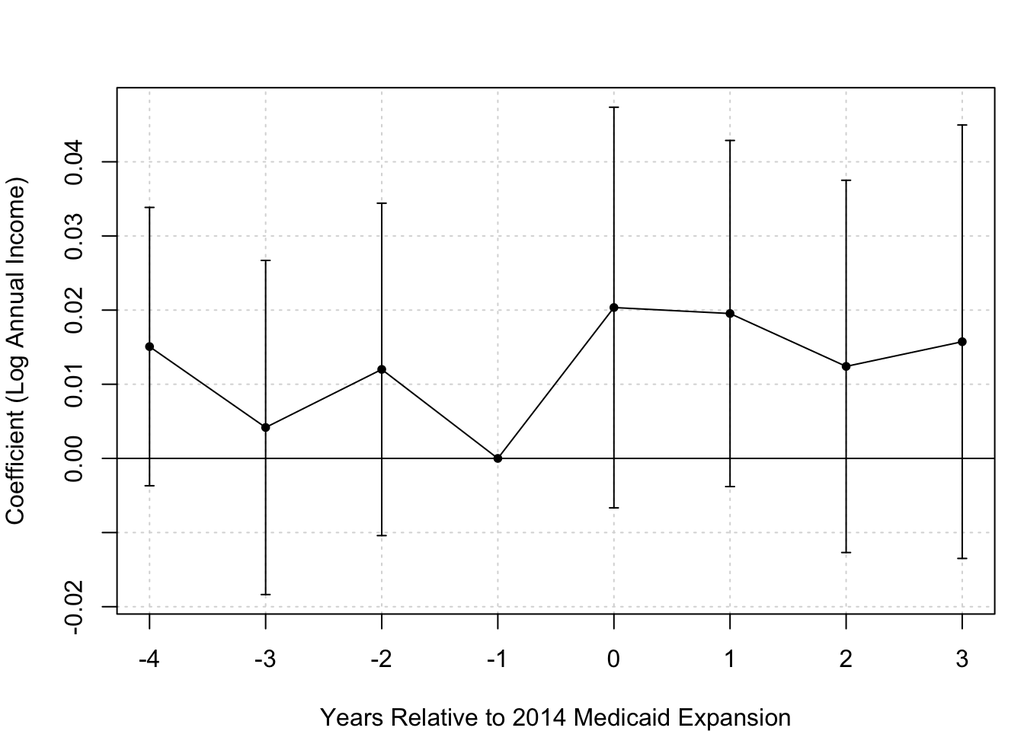

Figure 3 plots event study estimates for healthcare workers. Pre-period coefficients for years -4 through -1 are small and statistically indistinguishable from zero, supporting the parallel trends assumption underlying the triple DiD design. The post-period estimates show no meaningful or significant break after 2014, consistent with the null result in Table 4.

```r
es_ps <- feols(
  log(INCWAGE) ~ i(rel_time, exp, ref = -1) +
             AGE + age_sq + college_plus + female + black + hispanic |
             STATEFIP + YEAR,
  data = reg_data %>% filter(public_service_worker == 1),
  weights = ~PERWT,
  cluster = ~STATEFIP
)

par(mar = c(4, 4, 3, 1))

iplot(es_ps,
      main = "",
      xlab = "Years Relative to 2014 Medicaid Expansion",
      ylab = "Coefficient (Log Annual Income)",
      col = "black",
      pt.join = TRUE,
      zero.par = list(col = "black", lwd = 1),
      ci.par = list(col = "black"),
      grid.par = list(col = "gray85", lty = 3),
      ref.line = FALSE)
```

**Plot**

**Figure 4.** Event Study — Public Service Workers (Placebo)

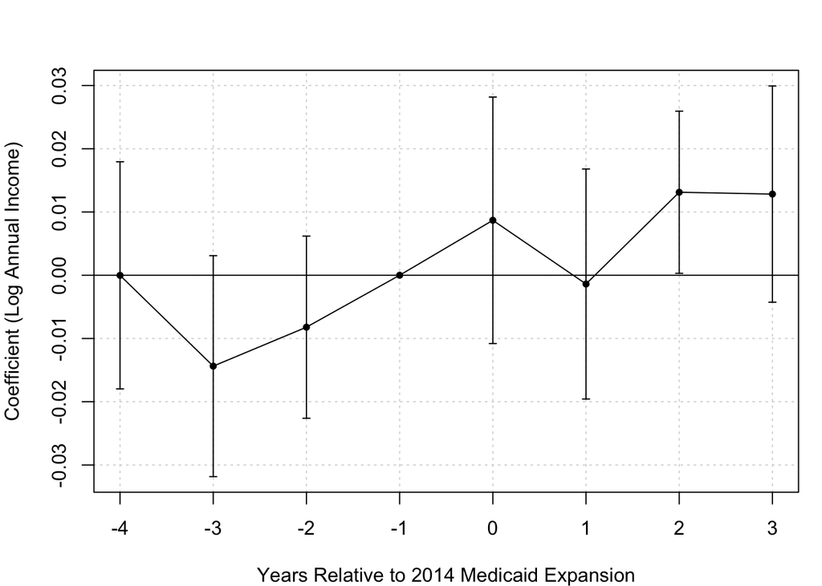

### Distributional Effects

```r
wage_percentiles <- analysis_sample_early %>%
  filter(healthcare_worker == 1, !is.na(expansion_year)) %>%
  group_by(YEAR) %>%
  summarize(
    p10 = quantile(INCWAGE, 0.10, na.rm = TRUE),
    p50 = quantile(INCWAGE, 0.50, na.rm = TRUE),
    p90 = quantile(INCWAGE, 0.90, na.rm = TRUE),
    .groups = "drop"
  ) %>%
  pivot_longer(cols = c(p10, p50, p90), names_to = "percentile", values_to = "wage") %>%
  mutate(
    percentile_label = case_when(
      percentile == "p10" ~ "10th Percentile",
      percentile == "p50" ~ "50th Percentile (Median)",
      percentile == "p90" ~ "90th Percentile"
    ),
    percentile_label = factor(percentile_label, levels = c(
      "10th Percentile", "50th Percentile (Median)", "90th Percentile"))
  )

ggplot(wage_percentiles, aes(x = YEAR, y = wage, linetype = percentile_label)) +
  geom_line(linewidth = 0.9, color = "black") +
  geom_point(size = 2, color = "black") +
  geom_vline(xintercept = 2014, linetype = "dashed", color = "black", linewidth = 0.8) +
  scale_x_continuous(breaks = 2010:2017) +
  scale_y_continuous(limits = c(0, 150000),
                     breaks = seq(0, 150000, 25000),
                     labels = scales::dollar_format()) +
  scale_linetype_manual(values = c(
    "10th Percentile"          = "dotted",
    "50th Percentile (Median)" = "dashed",
    "90th Percentile"          = "solid"),
    breaks = c("90th Percentile",
               "50th Percentile (Median)",
               "10th Percentile")) +
  labs(x = "Year", y = "Annual Wage", linetype = NULL) +
  theme_minimal(base_size = 12) +
  theme(legend.position = "bottom",
        axis.text.x = element_text(angle = 45, hjust = 1),
        legend.key.width = unit(2, "cm"),
        panel.grid.minor = element_blank())
```

**Plot**

**Figure 5.** Wage Distribution Across Percentiles - Healthcare Workers in Expansion States

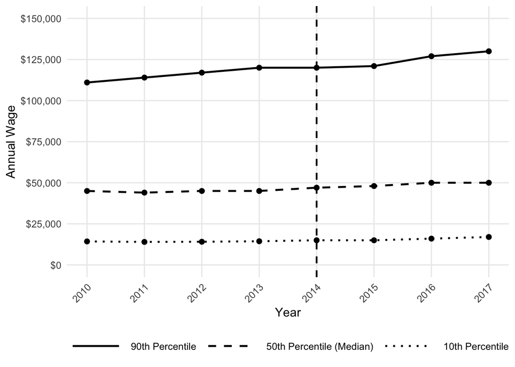

```r
wage_by_edu <- analysis_sample_early %>%
  filter(healthcare_worker == 1, !is.na(expansion_year)) %>%
  mutate(edu_group = case_when(
    EDUC >= 11 ~ "Postgrad",
    EDUC >= 10 ~ "Bachelors",
    TRUE       ~ "No College"
  )) %>%
  group_by(YEAR, edu_group) %>%
  summarize(mean_wage = mean(INCWAGE, na.rm = TRUE), .groups = "drop") %>%
  mutate(edu_group = factor(edu_group, levels = c("Postgrad", "Bachelors", "No College")))

ggplot(wage_by_edu, aes(x = YEAR, y = mean_wage, linetype = edu_group)) +
  geom_line(linewidth = 0.9, color = "black") +
  geom_point(size = 2, color = "black") +
  geom_vline(xintercept = 2014, linetype = "dashed", color = "black", linewidth = 0.8) +
  scale_x_continuous(breaks = 2010:2017) +
  scale_y_continuous(limits = c(0, 150000),
                     breaks = seq(0, 150000, 25000),
                     labels = scales::dollar_format()) +
  scale_linetype_manual(values = c("Postgrad"   = "solid",
                                   "Bachelors"  = "dashed",
                                   "No College" = "dotted")) +
  labs(x = "Year", y = "Mean Annual Wage", linetype = NULL) +
  theme_minimal(base_size = 12) +
  theme(legend.position = "bottom",
        legend.key.width = unit(2, "cm"),
        panel.grid.minor = element_blank())
```

**Plot**

**Figure 5b.** Mean Annual Wage Over Time by Education Level — Healthcare Workers in Expansion States

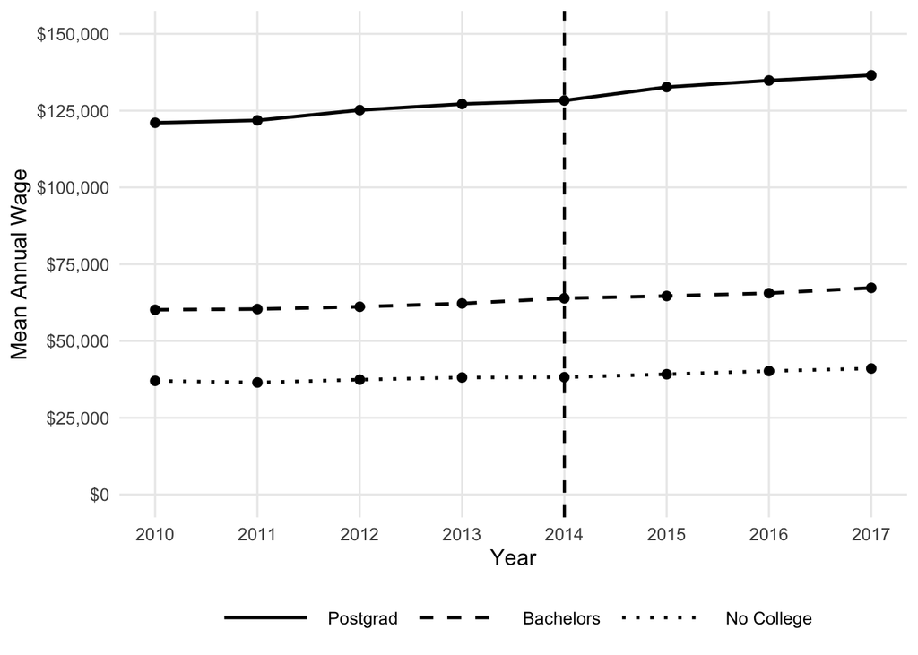

Figure 5 plots annual wages at the 10th, 50th, and 90th percentiles for healthcare workers in expansion states over time. Wage growth is concentrated at the top of the distribution, with the 90th percentile growing from approximately $112,000 to $130,000 between 2010 and 2017 while the 10th percentile remains essentially flat at around $15,000 to $18,000. The median shows modest growth from around $45,000 to $51,000 over the same period. Figure 5b shows the same pattern by education level, with postgrad occupations growing from approximately $122,000 to $138,000, while no-college occupations show more modest growth from around $35,000 to $42,000, and bachelors occupations growing from approximately $60,000 to $68,000.

### Event Study by Education Tier

```r
par(mar = c(4, 4, 3, 1))

{
  iplot(td_es[c(4L, 2L, 3L)],
        main = "",
        xlab = "Year",
        ylab = "Coefficient (Log Annual Income)",
        col = c("black", "blue", "red"),
        pt.pch = c(16, 17, 15),
        ci.col = c("black", "blue", "red"),
        zero.par = list(col = "black", lwd = 1),
        grid.par = list(col = "gray85", lty = 3),
        ref.line = FALSE,
        ylim = c(-0.08, 0.13))

  axis(1, at = seq(2010, 2017, by = 1))

  legend(x = 2015.5, y = 0.13,
         legend = c("Postgrad", "Bachelors", "No College"),
         pch = c(16, 17, 15),
         lty = 1,
         col = c("black", "blue", "red"),
         bty = "n")
}
```

**Plot**

**Figure 6.** Event Study by Education Tier — Healthcare Workers

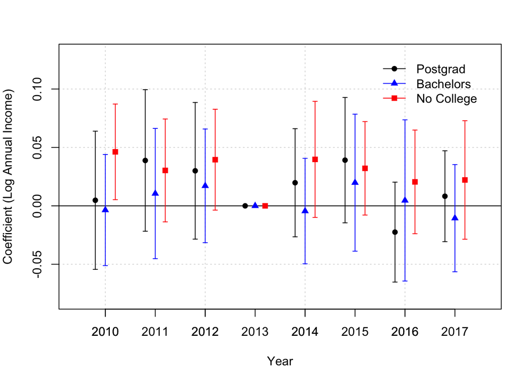

Figure 6 presents event study estimates by education tier. All three tiers collapse to zero at 2013, the reference year, as expected. Pre-period coefficients for the postgrad tier are small and statistically insignificant, supporting parallel trends for that subgroup. The no-college tier shows a statistically significant coefficient at 2010, suggesting some pre-existing differential trend for that group, though the coefficient is small in magnitude at approximately 0.05 log points. The bachelors tier shows some pre-period variation at 2010 and 2011, though these coefficients remain statistically insignificant given the wide confidence intervals. Post-period estimates are small and statistically insignificant across all three education tiers, consistent with the null result in Table 4.

### Robustness Checks

```r
tab_income <- modelsummary(
  list(
    "Postgrad"   = td_table[[4]],
    "Bachelors"  = td_table[[2]],
    "No College" = td_table[[3]]
  ),
  coef_map = c("hc:post:exp" = "HC x Post x Expansion (delta)"),
  gof_map = c("nobs", "r.squared"),
  stars = c("*" = 0.1, "**" = 0.05, "***" = 0.01),
  output = "dataframe"
)

tab_wage <- modelsummary(
  list(
    "Postgrad"   = td_table_wage[[4]],
    "Bachelors"  = td_table_wage[[2]],
    "No College" = td_table_wage[[3]]
  ),
  coef_map = c("hc:post:exp" = "HC x Post x Expansion (delta)"),
  gof_map = c("nobs", "r.squared"),
  stars = c("*" = 0.1, "**" = 0.05, "***" = 0.01),
  output = "dataframe"
)

tab_hours <- modelsummary(
  list(
    "Postgrad"   = td_table_hours[[4]],
    "Bachelors"  = td_table_hours[[2]],
    "No College" = td_table_hours[[3]]
  ),
  coef_map = c("hc:post:exp" = "HC x Post x Expansion (delta)"),
  gof_map = c("nobs", "r.squared"),
  stars = c("*" = 0.1, "**" = 0.05, "***" = 0.01),
  output = "dataframe"
)

names(tab_wage)[4:6]  <- names(tab_income)[4:6]
names(tab_hours)[4:6] <- names(tab_income)[4:6]

separator_income <- tab_income[1, ]
separator_income[, ] <- ""
separator_income[1, "term"] <- "Log Annual Income"

separator_wage <- tab_income[1, ]
separator_wage[, ] <- ""
separator_wage[1, "term"] <- "Log Hourly Wage"

separator_hours <- tab_income[1, ]
separator_hours[, ] <- ""
separator_hours[1, "term"] <- "Hours Worked"

combined <- rbind(separator_income, tab_income, separator_wage, tab_wage, separator_hours, tab_hours)

combined |>
  select(-part, -statistic) |>
  mutate(term = case_when(
    term == lag(term) & term != "" ~ "",
    TRUE ~ term
  )) |>
  gt() |>
  tab_style(
    style = list(
      cell_text(weight = "bold"),
      cell_fill(color = "#f0f0f0")
    ),
    locations = cells_body(
      rows = term %in% c("Log Annual Income", "Log Hourly Wage", "Hours Worked")
    )
  ) |>
  tab_style(
    style = cell_borders(sides = "top", color = "black", weight = px(2)),
    locations = cells_body(
      rows = term %in% c("Log Annual Income", "Log Hourly Wage", "Hours Worked")
    )
  ) |>
  cols_label(term = "") |>
  tab_source_note("Standard errors clustered at the state level. PERWT weighted.
                  Each column compares healthcare workers in the given education tier
                  to public service workers in the same education tier. All columns
                  use state x year, HC x year, and HC x state fixed effects and include
                  controls for age, age squared, education, sex, and race/ethnicity.")
```

Table 5: Robustness — Triple DiD Across Outcome Variables and Education Tiers.

|  | Postgrad | Bachelors | No College |
| --- | --- | --- | --- |
| Log Annual Income |  |  |  |
| HC x Post x Expansion (delta) | -0.008 | -0.004 | 0.000 |
|  | (0.015) | (0.013) | (0.017) |
| Num.Obs. | 704076 | 360529 | 666325 |
| R2 | 0.235 | 0.119 | 0.139 |
| Log Hourly Wage |  |  |  |
| HC x Post x Expansion (delta) | -0.013 | -0.005 | 0.009 |
|  | (0.013) | (0.010) | (0.011) |
| Num.Obs. | 704076 | 360529 | 666325 |
| R2 | 0.265 | 0.174 | 0.155 |
| Hours Worked |  |  |  |
| HC x Post x Expansion (delta) | 0.069 | 0.055 | -0.058 |
|  | (0.175) | (0.180) | (0.174) |
| Num.Obs. | 704076 | 360529 | 666325 |
| R2 | 0.060 | 0.047 | 0.079 |

Standard errors clustered at the state level. PERWT weighted. Each column compares healthcare workers in the given education tier to public service workers in the same education tier. All columns use state x year, HC x year, and HC x state fixed effects and include controls for age, age squared, education, sex, and race/ethnicity.

## Conclusion

This paper asks whether the ACA Medicaid expansion raised wages for healthcare workers. The pre-expansion data and predictions warned that there would be millions of newly insured patients entering a workforce that is constrained by licensing requirements, meaning healthcare organizations would need to increase wages to compete for scarce workers. Using American Community Survey microdata from 2010 to 2017, and a triple difference-in-differences design comparing healthcare workers to public service workers across expansion and non-expansion states, I find no evidence that this occurred.

The triple DiD coefficient is -0.005 under state and year fixed effects and -0.007 under the most demanding specification using state-by-year, healthcare-by-state, and healthcare-by-year fixed effects. Neither estimate is statistically significant at conventional levels. The null result is robust across outcome variables including log annual income, log hourly wages, and hours worked per week, and holds across all three education tiers of healthcare workers, when compared to public service workers of the same education level. The pre-period event study coefficients are generally near zero, supporting the parallel trends assumption underlying the identification strategy. The one exception is a single significant coefficient for no-college occupations at 2010, which is small in magnitude and does not constitute a systematic pre-trend.

These findings have two implications. First, the absence of wage effects suggests that the healthcare labor market was more flexible than pre-expansion predictions assumed. Frogner et al. (2015) and Parente et al. (2017) predicted that inelastic labor supply meeting a sudden demand shock would force wages upward, but this did not materialize. Second, Medicaid expansion did not translate into higher pay for healthcare workers over this period. Whether wage pressure emerged after 2017 as patient demand continued to build, or whether effects were concentrated in specific occupations that broad education tiers cannot pick up, remains an open question.

Several limitations are worth noting. First, the sample ends in 2017, which may not be enough time to capture wage adjustments that build slowly as sustained patient demand increases gradually. Second, the ACS records weeks worked in brackets rather than exact numbers, introducing some measurement error into the hourly wage construction. Third, assigning each occupation a single education tier may hide effects concentrated within specific roles, such as registered nurses or physician assistants, rather than spread evenly across a broad skill group.

One promising direction for future research is examining whether employers offset the absence of wage gains by adjusting non-wage compensation. Matta et al. (2024) find that some employers reduced health insurance coverage for low-wage workers after expansion, effectively replacing private benefits with Medicaid. Whether this pattern extends to other forms of compensation, such as paid time off, retirement contributions, or scheduling flexibility, and whether it varies across the wage distribution, remains an open question.

## References

Dillender, M. (2022). How do Medicaid expansions affect the demand for healthcare workers? Evidence from vacancy postings. *Journal of Human Resources*, 57(4), 1350-1393.

DiNardi, M. (2021). Affordable Care Act Medicaid expansions and the nurse labor market. *Southern Economic Journal*, 88(1), 360-391.

Duggan, M., Goda, G. S., & Jackson, E. (2019). The effects of the Affordable Care Act on health insurance coverage and labor market outcomes. *AEJ: Economic Policy*, 11(4), 164-202.

Frean, M., Gruber, J., & Sommers, B. D. (2017). Premium subsidies, the mandate, and Medicaid expansion: Coverage effects of the Affordable Care Act. *New England Journal of Medicine*, 376(12), 1145-1153.

Frogner, B. K., Spetz, J., Parente, S. T., & Oberlin, S. (2015). The demand for health care workers post-ACA. *International Journal of Health Economics and Management*, 15(1), 139-151.

Gooptu, A., Moriya, A. S., Simon, K. I., & Sommers, B. D. (2016). Medicaid expansion did not result in significant employment changes or job reductions in 2014. *Health Affairs*, 35(1), 111-118.

Kaestner, R., Garrett, B., Chen, J., Gangopadhyaya, A., & Fleming, C. (2017). Effects of ACA Medicaid expansions on health insurance coverage and labor supply. *Journal of Policy Analysis and Management*, 36(3), 608-642.

Kleiner, M. M., & Krueger, A. B. (2013). Analyzing the extent and influence of occupational licensing on the labor market. *Journal of Labor Economics*, 31(S1), S173-S202.

Leung, P., & Mas, A. (2018). Employment effects of the Affordable Care Act Medicaid expansions. *Industrial Relations*, 57(2), 206-234.

Matta, S., Chatterjee, P., & Venkataramani, A. S. (2024). Changes in health care workers’ economic outcomes following Medicaid expansion. *JAMA*, 331(8), 687-695. https://doi.org/10.1001/jama.2023.27014

Meille, G., & Post, B. (2023). The effects of the Medicaid expansion on hospital utilization, employment, and capital. *Medical Care Research and Review*, 80(2), 165-174.

Miller, S., & Wherry, L. R. (2017). Health and access to care during the first 2 years of the ACA Medicaid expansions. *New England Journal of Medicine*, 376(10), 947-956.

Parente, S. T., Feldman, R., Spetz, J., Dowd, B., & Baggett, E. E. (2017). Wage growth for the health care workforce: Projecting the Affordable Care Act impact. *Health Services Research*, 52(2), 741-762.

Ruggles, S., Flood, S., Sobek, M., Backman, D., Chen, A., Cooper, G., Richards, S., Rodgers, R., & Schouweiler, M. (2024). IPUMS USA: Version 15.0 [dataset]. Minneapolis, MN: IPUMS. https://doi.org/10.18128/D010.V15.0

Sommers, B. D., Gunja, M. Z., Finegold, K., & Musco, T. (2015). Changes in self-reported insurance coverage, access to care, and health under the Affordable Care Act. *JAMA*, 314(4), 366-374.

Staiger, D. O., Auerbach, D. I., & Buerhaus, P. I. (2012). Registered nurse labor supply and the recession — are we in a bubble? *New England Journal of Medicine*, 366(16), 1463-1465.

Xu, L., & Sharma, H. (2023). Effect of Medicaid expansion on health insurance for low-income nursing home aides. *Medical Care Research and Review*, 80(1), 121-129.

Xu, L., Sharma, H., & Wehby, G. L. (2024). Effects of the Affordable Care Act Medicaid expansions on the employment and work hours of nursing assistants in hospitals and nursing homes. *Journal of Applied Gerontology*, 43(8), 1057-1067.

# Appendix

## Appendix A: State-Level Summary

```r
state_lookup <- tibble(
  STATEFIP = c(1,2,4,5,6,8,9,10,11,12,13,15,16,17,18,
               19,20,21,22,23,24,25,26,27,28,29,30,31,
               32,33,34,35,36,37,38,39,40,41,42,44,45,
               46,47,48,49,50,51,53,54,55,56),
  State = c("Alabama","Alaska","Arizona","Arkansas",
            "California","Colorado","Connecticut",
            "Delaware","Washington DC","Florida","Georgia",
            "Hawaii","Idaho","Illinois","Indiana",
            "Iowa","Kansas","Kentucky","Louisiana",
            "Maine","Maryland","Massachusetts",
            "Michigan","Minnesota","Mississippi",
            "Missouri","Montana","Nebraska","Nevada",
            "New Hampshire","New Jersey","New Mexico",
            "New York","North Carolina","North Dakota",
            "Ohio","Oklahoma","Oregon","Pennsylvania",
            "Rhode Island","South Carolina","South Dakota",
            "Tennessee","Texas","Utah","Vermont",
            "Virginia","Washington","West Virginia",
            "Wisconsin","Wyoming")
)

table4_data <- analysis_sample %>%
  mutate(
    expansion_status = case_when(
      is.na(expansion_year) ~ "Non-Expansion",
      expansion_year == 2014 ~ "Expansion (2014) - Included",
      expansion_year > 2014 ~ paste0("Late Adopter (", expansion_year, ") - Excluded")
    )
  ) %>%
  group_by(STATEFIP, expansion_status) %>%
  summarize(
    N = n(),
    `Healthcare Workers` = sum(healthcare_worker),
    `Public Service Workers` = sum(public_service_worker),
    `Mean Wage` = mean(hourly_wage, na.rm = TRUE),
    .groups = "drop"
  ) %>%
  left_join(state_lookup, by = "STATEFIP") %>%
  select(State, expansion_status, N,
         `Healthcare Workers`, `Public Service Workers`, `Mean Wage`) %>%
  rename(`Expansion Status` = expansion_status) %>%
  arrange(State)

kable(table4_data,
      caption = "State-Level Sample Summary (All States)",
      format.args = list(big.mark = ","),
      digits = 2)
```

Table 6: State-Level Sample Summary (All States)

State-Level Sample Summary (All States)

| State | Expansion Status | N | Healthcare Workers | Public Service Workers | Mean Wage |
| --- | --- | --- | --- | --- | --- |
| Alabama | Non-Expansion | 26,609 | 11,362 | 15,247 | 25.67 |
| Alaska | Late Adopter (2015) - Excluded | 4,051 | 1,263 | 2,788 | 29.96 |
| Arizona | Expansion (2014) - Included | 36,580 | 13,917 | 22,663 | 28.55 |
| Arkansas | Expansion (2014) - Included | 16,374 | 6,976 | 9,398 | 23.64 |
| California | Expansion (2014) - Included | 210,405 | 75,500 | 134,905 | 36.60 |
| Colorado | Expansion (2014) - Included | 34,241 | 12,609 | 21,632 | 29.57 |
| Connecticut | Expansion (2014) - Included | 27,251 | 10,216 | 17,035 | 35.47 |
| Delaware | Expansion (2014) - Included | 5,820 | 2,269 | 3,551 | 30.73 |
| Florida | Non-Expansion | 115,250 | 47,766 | 67,484 | 28.47 |
| Georgia | Non-Expansion | 58,230 | 21,172 | 37,058 | 27.10 |
| Hawaii | Expansion (2014) - Included | 8,855 | 3,125 | 5,730 | 30.43 |
| Idaho | Non-Expansion | 8,626 | 3,394 | 5,232 | 24.10 |
| Illinois | Expansion (2014) - Included | 80,427 | 31,053 | 49,374 | 30.94 |
| Indiana | Late Adopter (2015) - Excluded | 37,894 | 16,460 | 21,434 | 25.46 |
| Iowa | Expansion (2014) - Included | 18,959 | 8,048 | 10,911 | 25.09 |
| Kansas | Non-Expansion | 19,069 | 7,665 | 11,404 | 24.13 |
| Kentucky | Expansion (2014) - Included | 26,365 | 11,362 | 15,003 | 26.10 |
| Louisiana | Late Adopter (2016) - Excluded | 27,541 | 11,070 | 16,471 | 26.44 |
| Maine | Late Adopter (2019) - Excluded | 8,727 | 3,661 | 5,066 | 25.06 |
| Maryland | Expansion (2014) - Included | 43,728 | 15,491 | 28,237 | 34.94 |
| Massachusetts | Expansion (2014) - Included | 52,197 | 20,362 | 31,835 | 34.62 |
| Michigan | Expansion (2014) - Included | 56,137 | 25,327 | 30,810 | 28.18 |
| Minnesota | Expansion (2014) - Included | 35,966 | 15,799 | 20,167 | 28.53 |
| Mississippi | Non-Expansion | 17,044 | 7,088 | 9,956 | 23.19 |
| Missouri | Non-Expansion | 37,629 | 15,751 | 21,878 | 25.38 |
| Montana | Late Adopter (2016) - Excluded | 5,994 | 2,337 | 3,657 | 24.65 |
| Nebraska | Non-Expansion | 12,139 | 5,116 | 7,023 | 23.88 |
| Nevada | Expansion (2014) - Included | 13,556 | 4,933 | 8,623 | 31.81 |
| New Hampshire | Expansion (2014) - Included | 9,754 | 4,023 | 5,731 | 29.94 |
| New Jersey | Expansion (2014) - Included | 62,261 | 22,530 | 39,731 | 35.97 |
| New Mexico | Expansion (2014) - Included | 11,352 | 4,039 | 7,313 | 25.93 |
| New York | Expansion (2014) - Included | 150,852 | 55,901 | 94,951 | 34.93 |
| North Carolina | Non-Expansion | 62,333 | 25,645 | 36,688 | 26.46 |
| North Dakota | Expansion (2014) - Included | 4,475 | 1,971 | 2,504 | 25.19 |
| Ohio | Expansion (2014) - Included | 73,127 | 33,199 | 39,928 | 27.08 |
| Oklahoma | Non-Expansion | 20,440 | 8,284 | 12,156 | 24.17 |
| Oregon | Expansion (2014) - Included | 23,916 | 9,152 | 14,764 | 30.05 |
| Pennsylvania | Late Adopter (2015) - Excluded | 83,353 | 37,094 | 46,259 | 28.88 |
| Rhode Island | Expansion (2014) - Included | 8,108 | 3,332 | 4,776 | 32.25 |
| South Carolina | Non-Expansion | 27,833 | 11,215 | 16,618 | 25.80 |
| South Dakota | Non-Expansion | 5,186 | 2,285 | 2,901 | 22.72 |
| Tennessee | Non-Expansion | 38,877 | 16,237 | 22,640 | 26.50 |
| Texas | Non-Expansion | 150,784 | 55,906 | 94,878 | 27.95 |
| Utah | Non-Expansion | 16,383 | 5,719 | 10,664 | 27.75 |
| Vermont | Expansion (2014) - Included | 4,761 | 1,687 | 3,074 | 28.09 |
| Virginia | Late Adopter (2019) - Excluded | 56,961 | 19,254 | 37,707 | 32.56 |
| Washington | Expansion (2014) - Included | 42,156 | 16,406 | 25,750 | 31.70 |
| Washington DC | Expansion (2014) - Included | 6,193 | 967 | 5,226 | 46.22 |
| West Virginia | Expansion (2014) - Included | 10,927 | 4,873 | 6,054 | 24.98 |
| Wisconsin | Non-Expansion | 35,937 | 16,179 | 19,758 | 27.16 |
| Wyoming | Non-Expansion | 3,818 | 1,208 | 2,610 | 25.72 |

```r
occ_labels <- tibble::tribble(
  ~OCC,  ~`Occupation Name`,
  3000,  "Chiropractors",
  3010,  "Dentists",
  3030,  "Dietitians and Nutritionists",
  3040,  "Optometrists",
  3050,  "Pharmacists",
  3060,  "Physicians and Surgeons",
  3090,  "Podiatrists",
  3110,  "Audiologists",
  3120,  "Occupational Therapists",
  3130,  "Physical Therapists",
  3140,  "Radiation Therapists",
  3150,  "Recreational Therapists",
  3160,  "Respiratory Therapists",
  3200,  "Speech-Language Pathologists",
  3210,  "Exercise Physiologists",
  3220,  "Therapists, All Other",
  3230,  "Veterinarians",
  3240,  "Health Diagnosing/Treating Practitioners, Other",
  3250,  "Dental Hygienists",
  3255,  "Registered Nurses",
  3256,  "Nurse Anesthetists",
  3257,  "Nurse Midwives",
  3258,  "Nurse Practitioners",
  3260,  "Licensed Practical/Vocational Nurses",
  3300,  "Medical Records/Health Info Technicians",
  3310,  "Opticians",
  3330,  "Clinical Lab Technologists/Technicians",
  3400,  "Diagnostic Medical Sonographers",
  3420,  "Radiologic Technologists",
  3430,  "MRI Technologists",
  3500,  "Emergency Med Technicians/Paramedics",
  3510,  "Health Practitioner Support Technologists",
  3520,  "Surgical Technologists",
  3530,  "Psychiatric Technicians",
  3540,  "Veterinary Technologists/Technicians",
  3545,  "Dental Assistants",
  3550,  "Medical Assistants",
  3600,  "Nursing, Psychiatric & Home Health Aides",
  3610,  "Occupational Therapy Assistants/Aides",
  3620,  "Physical Therapist Assistants/Aides",
  3630,  "Massage Therapists",
  3640,  "Personal Care Aides",
  3645,  "Phlebotomists",
  3646,  "Medical Transcriptionists",
  3647,  "Pharmacy Aides",
  3648,  "Veterinary Assistants/Lab Animal Caretakers",
  3649,  "Healthcare Support Workers, All Other",
  3655,  "Orderlies and Attendants"
)

occ_tier_table <- occ_edu %>%
  left_join(occ_labels, by = "OCC") %>%
  left_join(
    analysis_sample_early %>%
      filter(healthcare_worker == 1) %>%
      group_by(OCC) %>%
      summarize(
        N = n(),
        `Weighted N` = sum(PERWT),
        `% Postgrad` = mean(EDUC >= 11, na.rm = TRUE) * 100,
        `% Bachelors` = mean(EDUC == 10, na.rm = TRUE) * 100,
        `% No College` = mean(EDUC < 10, na.rm = TRUE) * 100,
        .groups = "drop"
      ),
    by = "OCC"
  ) %>%
  arrange(edu_tier, OCC) %>%
  rename(
    `OCC Code` = OCC,
    `Modal Tier` = edu_tier
  ) %>%
  select(`OCC Code`, `Occupation Name`, `Modal Tier`, N, `Weighted N`,
         `% Postgrad`, `% Bachelors`, `% No College`)

kable(occ_tier_table,
      digits = 1,
      format.args = list(big.mark = ","))
```

Table 7: OCC-Level Education Tier Assignments (Healthcare Workers)

| OCC Code | Occupation Name | Modal Tier | N | Weighted N | % Postgrad | % Bachelors | % No College |
| --- | --- | --- | --- | --- | --- | --- | --- |
| 2,010 | NA | bachelors | NA | NA | NA | NA | NA |
| 2,015 | NA | bachelors | NA | NA | NA | NA | NA |
| 2,600 | NA | bachelors | NA | NA | NA | NA | NA |
| 2,630 | NA | bachelors | NA | NA | NA | NA | NA |
| 2,700 | NA | bachelors | NA | NA | NA | NA | NA |
| 2,710 | NA | bachelors | NA | NA | NA | NA | NA |
| 2,720 | NA | bachelors | NA | NA | NA | NA | NA |
| 2,810 | NA | bachelors | NA | NA | NA | NA | NA |
| 2,825 | NA | bachelors | NA | NA | NA | NA | NA |
| 2,830 | NA | bachelors | NA | NA | NA | NA | NA |
| 2,840 | NA | bachelors | NA | NA | NA | NA | NA |
| 2,850 | NA | bachelors | NA | NA | NA | NA | NA |
| 2,920 | NA | bachelors | NA | NA | NA | NA | NA |
| 3,030 | Dietitians and Nutritionists | bachelors | 5,656 | 568,625 | 35.3 | 39.9 | 24.8 |
| 3,210 | Exercise Physiologists | bachelors | 721 | 71,605 | 16.2 | 62.4 | 21.4 |
| 3,255 | Registered Nurses | bachelors | 192,513 | 19,109,883 | 10.4 | 46.7 | 42.9 |
| 2,016 | NA | no_college | NA | NA | NA | NA | NA |
| 2,025 | NA | no_college | NA | NA | NA | NA | NA |
| 2,060 | NA | no_college | NA | NA | NA | NA | NA |
| 2,145 | NA | no_college | NA | NA | NA | NA | NA |
| 2,160 | NA | no_college | NA | NA | NA | NA | NA |
| 2,300 | NA | no_college | NA | NA | NA | NA | NA |
| 2,340 | NA | no_college | NA | NA | NA | NA | NA |
| 2,440 | NA | no_college | NA | NA | NA | NA | NA |
| 2,540 | NA | no_college | NA | NA | NA | NA | NA |
| 2,740 | NA | no_college | NA | NA | NA | NA | NA |
| 2,750 | NA | no_college | NA | NA | NA | NA | NA |
| 2,760 | NA | no_college | NA | NA | NA | NA | NA |
| 2,800 | NA | no_college | NA | NA | NA | NA | NA |
| 2,860 | NA | no_college | NA | NA | NA | NA | NA |

[output cut: 66 more lines]